# Fir diameter growth analysis, all years - fire footprints

Carmen

November 14, 2017

# Load data

```r
load(file = "~/../Documents/Shrubs-Seedlings/compiled_data/fire_footprints/master_seedlings2.Rdata")
```

# Filter out firs and fires with very few firs

```r
df <- df[df$Species%in%c("ABCO","ABMA", "PSME") & !df$Fire %in% c("PLKN","FRDS"),]
df$Species <- as.factor(df$Species)
df %>%
  group_by(Fire) %>%
  summarise(n())
```

```
## # A tibble: 4 x 2
##   Fire  `n()`
##   <fct> <int>
## 1 AMCR    233
## 2 CLVD     31
## 3 STAR     31
## 4 WRTS     35
```

# Take a look

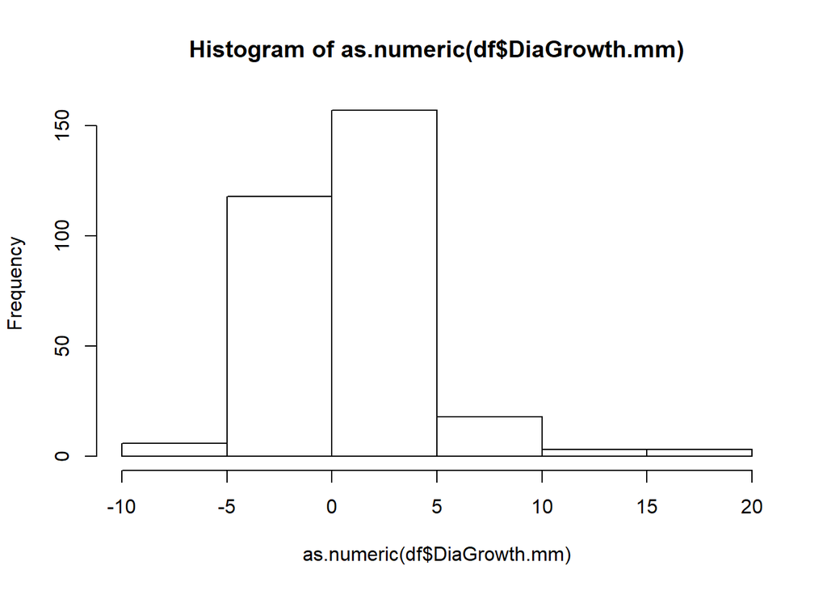

```r
hist(as.numeric(df$DiaGrowth.mm))
```

```r
summary(df$DiaGrowth.mm)
```

```
##    Min. 1st Qu.  Median    Mean 3rd Qu.    Max.    NA's
##  -8.650  -1.000   0.650   1.006   2.150  19.750      25
```

```r
df %>% filter(is.na(DiaGrowth.mm))
```

```
## # A tibble: 25 x 61
##    Sdlg  Species Fire  FirePatch Elevation Slope.Deg Aspect.deg
##    <chr> <fct>   <fct> <fct>         <dbl>     <dbl>      <dbl>
##  1 58    ABCO    AMCR  AMCR-NE        1966        17        188
##  2 80    ABCO    AMCR  AMCR-2         1701        15        290
##  3 80    ABCO    AMCR  AMCR-2         1701        15        290
##  4 81    ABCO    AMCR  AMCR-2         1701        15        290
##  5 81    ABCO    AMCR  AMCR-2         1701        15        290
##  6 82    ABCO    AMCR  AMCR-2         1701        15        290
##  7 83    ABCO    AMCR  AMCR-2         1701        14        290
##  8 83    ABCO    AMCR  AMCR-2         1701        14        290
##  9 85    ABCO    AMCR  AMCR-2         1701        14        290
## 10 86    ABCO    AMCR  AMCR-2         1701        14        290
## # ... with 15 more rows, and 54 more variables: BasDia2016.cm <dbl>,
## #   LastYearGrth.cm <dbl>, Light_File <fct>, DIFN.all <dbl>,
## #   ImmedAboveSpp <fct>, ImmedAboveHt.cm <int>, ShrubSpp01 <fct>,
## #   ShrubSpp02 <fct>, ShrubSpp03 <fct>, Cov1 <int>, Cov2 <int>,
## #   Cov3 <int>, Ht1 <dbl>, Ht2 <dbl>, Ht3 <dbl>, Cov1.2 <int>,
## #   Cov1.3 <int>, Ht1.2 <dbl>, Ht1.3 <dbl>, Genus <fct>, ShrG1 <fct>,
## #   IAG <fct>, Years <int>, Date <fct>, LAI <dbl>, DIFN.53 <dbl>,
## #   DataSheet2017 <chr>, Map <chr>, Status <chr>, BasDia2017.mm.1 <dbl>,
## #   BasDia2017.mm.2 <dbl>, notes <chr>, BasDia2017.mm.ave <dbl>,
## #   BasDia2016.mm <dbl>, DiaGrowth.mm <dbl>, Year <fct>, VertGrowth <dbl>,
## #   shrubarea1 <dbl>, shrubarea2 <dbl>, shrubarea3 <dbl>, Ht_cm <dbl>,
## #   VertGrowth_Rel <dbl>, Ht_norm <dbl>, shrubarea2_sqrt_norm <dbl>,
## #   Y <dbl>, X <dbl>, file_lat <chr>, Aspect.rad <dbl>, Slope.rad <dbl>,
## #   Lat.rad <dbl>, Aspect.rad.fold.NS <dbl>, Aspect.rad.fold.NESW <dbl>,
## #   incidrad <dbl>, heatload <dbl>
```

```r
df %>% group_by(Species) %>%
  summarise(n())
```

```
## # A tibble: 1 x 2
##   Species `n()`
##   <fct>   <int>
## 1 ABCO      330
```

# Clean

## Take out trees with no second dia measurement

```r
df <- df %>% filter(!(BasDia2017.mm.2== 0 & BasDia2017.mm.1 == 0))
```

## Restructure so there’s only one row per seedling

```r
df_dia <- df %>%
  select(-VertGrowth, -VertGrowth_Rel, -Year) %>%
  distinct()
remove(df)
```

### A seedling was defined as an outlier using analysis of residuals after the fact

It had suspiciously lower basal diameter in 2017 compared to 2016, and I take it out here

```r
df_dia <- df_dia %>% filter(!(Fire == "CLVD" & Sdlg == "11"))
```

## Lump quercus with “other” shrub genus since it only has 3 observations

```r
df_dia <- df_dia %>%
  ungroup() %>%
  mutate(ShrG1 = ifelse(ShrG1 == "Quercus", "Other", as.character(ShrG1)))
df_dia$ShrG1 <- as.factor(df_dia$ShrG1)
```

# Calculate relative diameter growth

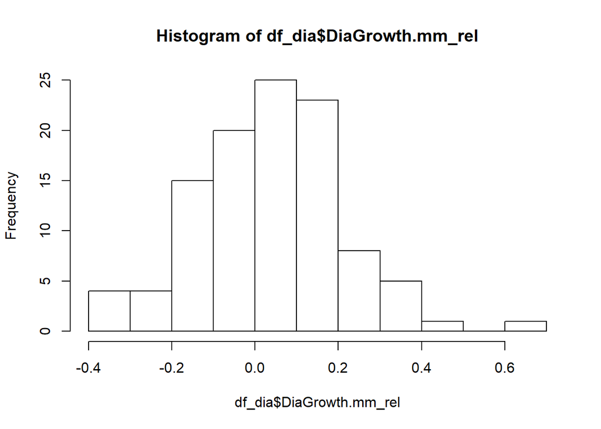

```r
df_dia <- df_dia %>%
  mutate(DiaGrowth.mm_rel = DiaGrowth.mm/(BasDia2016.cm*10))
hist(df_dia$DiaGrowth.mm_rel)
```

## Take out repeat row

```r
nrow(df_dia)
```

```
## [1] 106
```

```r
df_dia <- df_dia %>%
  filter(!(Sdlg == "117" & LAI == 0))
nrow(df_dia)
```

```
## [1] 105
```

## Take out outliers on both ends, defined as greater than two SD from the mean

```r
mean(df_dia$DiaGrowth.mm_rel) - 2*sd(df_dia$DiaGrowth.mm_rel)
```

```
## [1] -0.3089561
```

```r
mean(df_dia$DiaGrowth.mm_rel) + 2*sd(df_dia$DiaGrowth.mm_rel)
```

```
## [1] 0.3792455
```

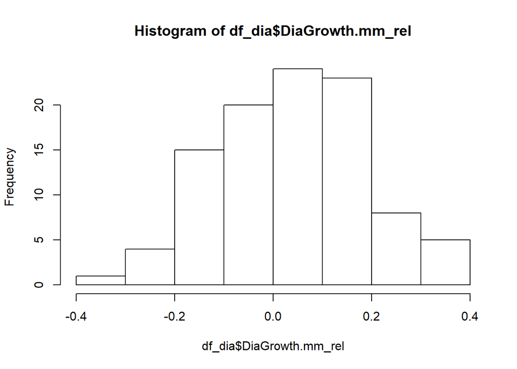

```r
df_dia <- df_dia %>%
  filter(!(DiaGrowth.mm_rel < (mean(df_dia$DiaGrowth.mm_rel) - 2*sd(df_dia$DiaGrowth.mm_rel)) |
             DiaGrowth.mm_rel > mean(df_dia$DiaGrowth.mm_rel) + 2*sd(df_dia$DiaGrowth.mm_rel)))
hist(df_dia$DiaGrowth.mm_rel)
```

```r
df_dia %>%
  filter(DiaGrowth.mm_rel < 0) %>%
  summarise(n())
```

```
## # A tibble: 1 x 1
##   `n()`
##   <int>
## 1    40
```

```r
39/nrow(df_dia)
```

```
## [1] 0.39
```

## Adjust so that no values are below 0

```r
df_dia <- df_dia %>%
  mutate(DiaGrowth.mm_rel = (DiaGrowth.mm_rel - min(df_dia$DiaGrowth.mm_rel)))
```

# Normalize variables that still need it

```r
normalize <- function(x) {
    return ((x - mean(x)) / sd(x))
  }
```

```r
df_dia <- df_dia %>%
  mutate(Cov1.2_norm = normalize(Cov1.2)) %>%
  mutate(Cov1.3_norm = normalize(Cov1.3)) %>%
  mutate(Ht_norm = normalize(Ht_cm)) %>%
  mutate(Ht_log_norm = normalize(log(Ht_cm)))
```

# Stats

## Mixed effects model: How does relative diameter growth relate to shrub area?

```r
f <- DiaGrowth.mm_rel ~  shrubarea2_sqrt_norm + Ht_log_norm
f_noshrubs <- DiaGrowth.mm_rel ~  Ht_norm
LM1 <- lme(f,data = df_dia, random = ~ 1|Fire, method = "ML")
LM1_noshrubs <- lme(f_noshrubs,data = df_dia, random = ~ 1|Fire, method = "ML")
anova(LM1, LM1_noshrubs)
```

```
##              Model df       AIC       BIC   logLik   Test  L.Ratio p-value
## LM1              1  5 -127.1639 -114.1381 68.58195
## LM1_noshrubs     2  4 -120.4107 -109.9900 64.20535 1 vs 2 8.753207  0.0031
```

# Look for patterns in residuals of mixed effects model

## In relation to fitted values

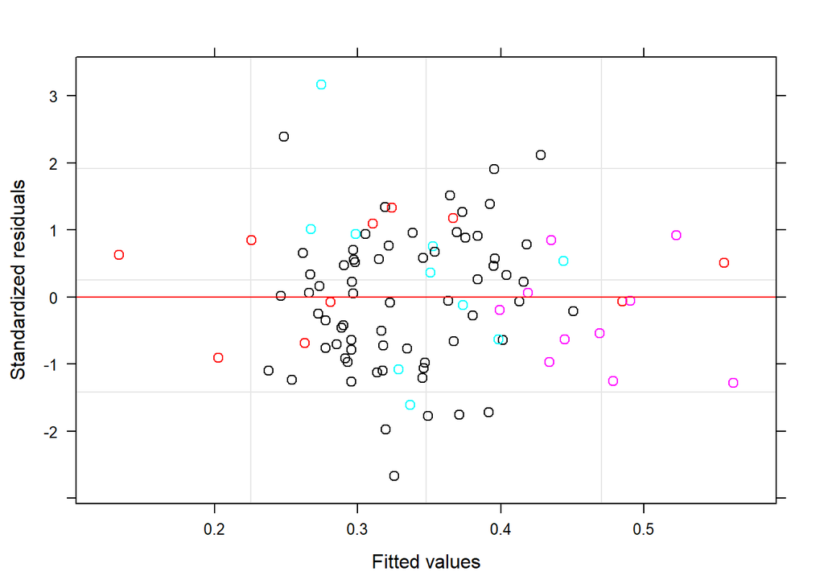

```r
E <- resid(LM1, type="normalized")
df_dia$resid <- E
plot(LM1, col = df_dia$Fire)
```

```r
df_dia[fitted.values(LM1)<0,]$resid
```

```
## numeric(0)
```

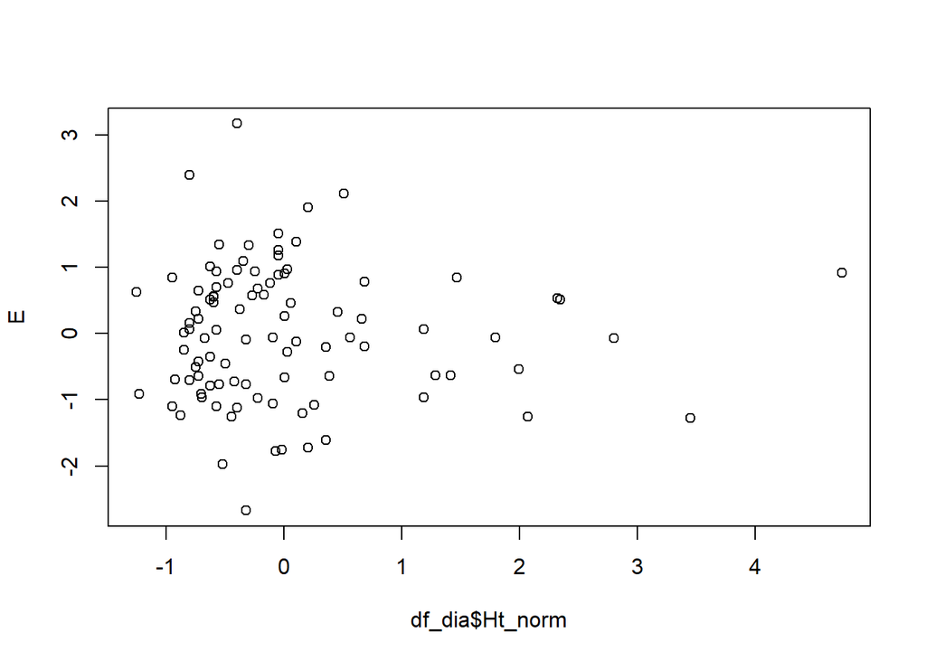

```r
plot(df_dia$Ht_norm, E)
```

## In relation to height

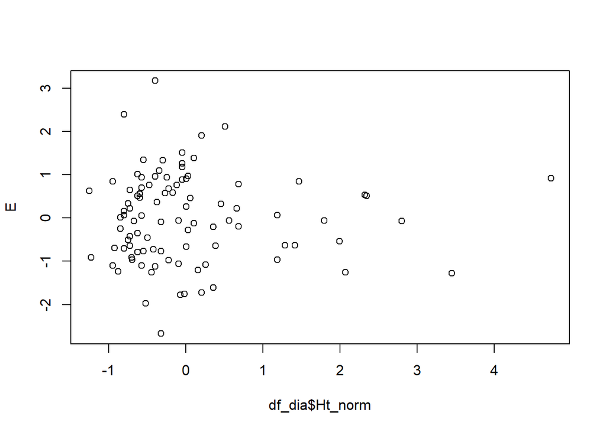

```r
plot(E~df_dia$Ht_norm)
```

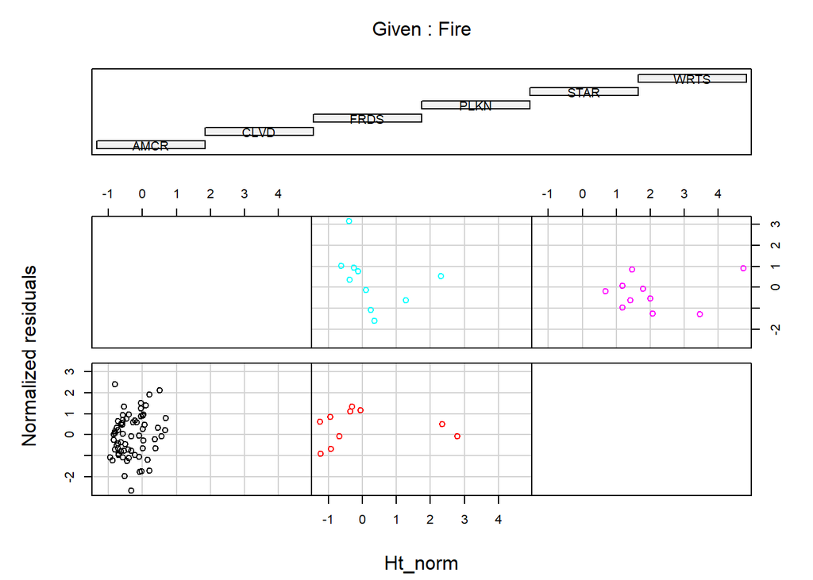

```r
coplot(E ~ Ht_norm | Fire, data=df_dia, ylab="Normalized residuals", col=df_dia$Fire)
```

## In relation to shrub area and fire

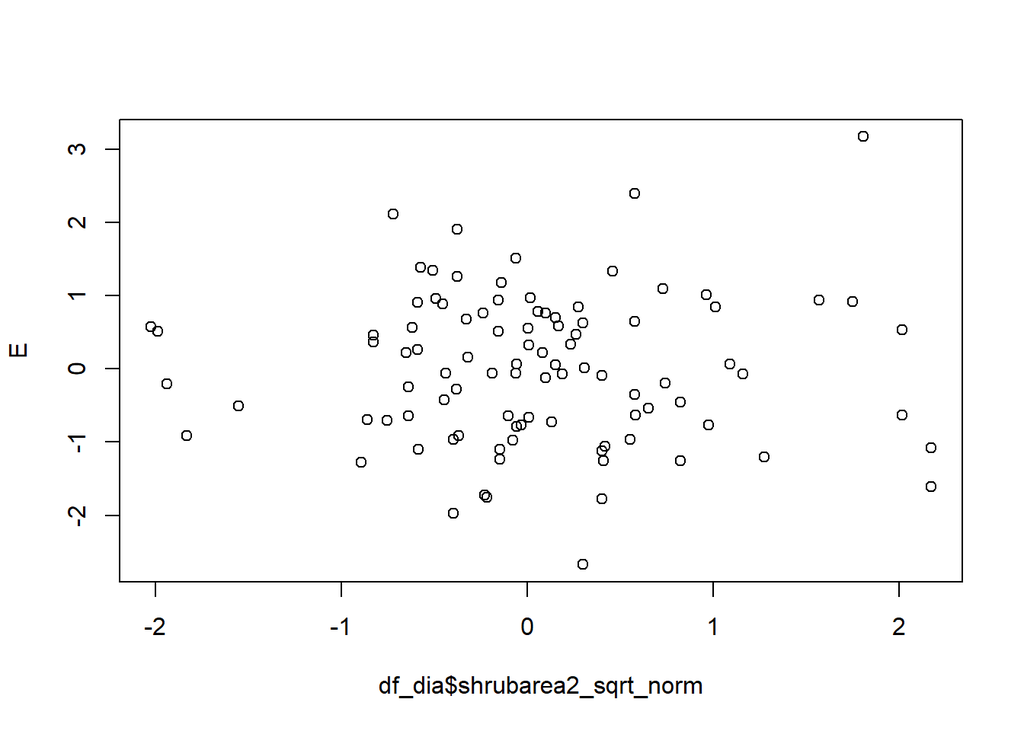

```r
plot(df_dia$shrubarea2_sqrt_norm, E)
```

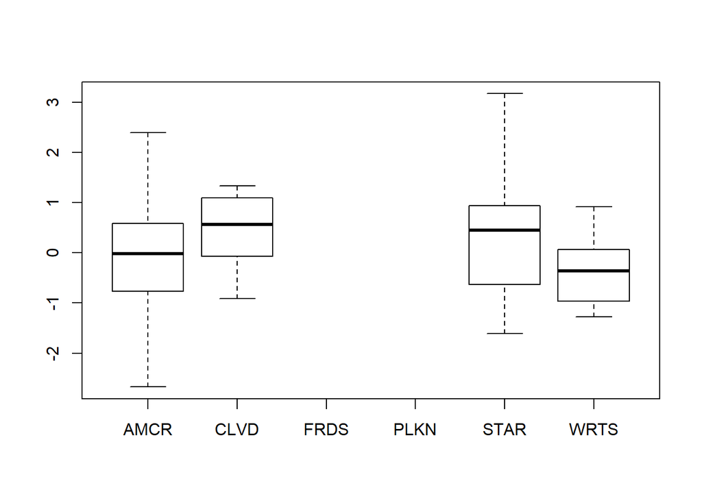

```r
plot(df_dia$Fire, E)
```

# Is the variance different between larger and smaller seedlings?

```r
sd(unlist(df_dia[df_dia$Ht_cm < median(df_dia$Ht_cm),"resid"]))
```

```
## [1] 1.036891
```

```r
sd(unlist(df_dia[df_dia$Ht_cm >= median(df_dia$Ht_cm),"resid"]))
```

```
## [1] 0.9824675
```

```r
sd(df_dia$resid)
```

```
## [1] 1.005038
```

```r
(sd(unlist(df_dia[df_dia$Ht_cm < median(df_dia$Ht_cm),"resid"])))/(sd(unlist(df_dia[df_dia$Ht_cm >= median(df_dia$Ht_cm),"resid"])))
```

```
## [1] 1.055395
```

Not bad.

# Plot

## Make fake data

```r
MyData <-  rbind(
  expand.grid(
    Fire = unique(df_dia$Fire),
    shrubarea2 = seq(min(df_dia$shrubarea2), max(df_dia$shrubarea2), length = 20),
    Ht_cm = seq(min(df_dia$Ht_cm), max(df_dia$Ht_cm), length = 20),
    Cov1.2 = seq(min(df_dia$Cov1.2), max(df_dia$Cov1.2), length = 20)
    )
)
```

## “Normalize” fake data, but use mean and sd from actual data

```r
normalize <- function(x) {
    return ((x - mean(x)) / sd(x))
  }
```

```r
MyData$shrubarea2_sqrt_norm <- (sqrt(MyData$shrubarea2) - mean(sqrt(df_dia$shrubarea2)))/sd(sqrt(df_dia$shrubarea2))

MyData$Ht_log_norm <- normalize(log(MyData$Ht_cm))
MyData$Cov1.2_norm <- (MyData$Cov1.2 - mean(df_dia$Cov1.2))/sd(df_dia$Cov1.2)
```

## Plot

```r
MyData$pred_simple <- predict(LM1, level = 0, newdata = MyData, type = "response")
```

### Summary plot

```r
MyData_summary_simple <- MyData %>%
  group_by(shrubarea2, Fire) %>%
  mutate(pred_simple = mean(pred_simple))

figure_summary <- ggplot(MyData_summary_simple)+
  labs(title = "Predicted fir seedling diameter growth (lines) \nand actual growth (points)")+
  ylab("Predicted relative seedling growth")+
  xlab("shrub cover * shrub height 0-2 m from seedling")+
  geom_line(aes(y = pred_simple, x = sqrt(shrubarea2)))+
  geom_point(data=df_dia, aes(x = sqrt(shrubarea2), y = DiaGrowth.mm_rel))
dev.off()
```

[figure not shown]

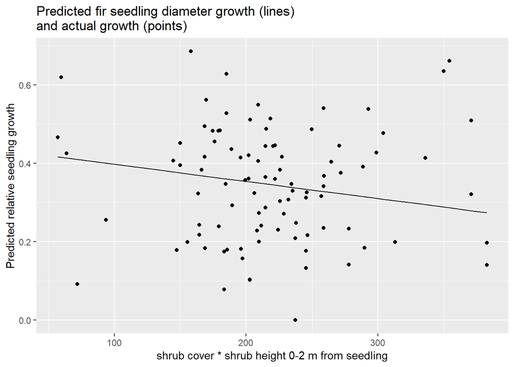

```r
figure_summary
```

```r
remove(MyData_summary_simple)
```

```r
df_dia %>%
  group_by(ShrG1) %>%
  summarise(n())
```

```
## # A tibble: 5 x 2
##   ShrG1     `n()`
##   <fct>     <int>
## 1 Arcto        25
## 2 Ceanothus    57
## 3 CHSE          9
## 4 LIDE          1
## 5 Other         8
```

# Add date measured in 2016??

# AIC table

## Find all possible variable combinations

```r
v1 <- c("shrubarea2_sqrt_norm", "Cov1.2_norm" , "Cov1.3_norm" , "IAG", "ShrG1", "shrubarea2_sqrt_norm:Ht_norm", "Cov1.2_norm:Ht_norm")
combs <- do.call("c", lapply(seq_along(v1), function(i) combn(v1, i, FUN = list)))
list.bad <- list()
for(i in 1:length(combs)){
  if("Cov1.2_norm" %in% combs[i][[1]] & "Cov1.3_norm" %in% combs[i][[1]])
    {
    list.bad <- c(list.bad, i)
    }
  if("shrubarea2_sqrt_norm" %in% combs[i][[1]] & ("Cov1.2_norm" %in% combs[i][[1]] | "Cov1.3_norm" %in% combs[i][[1]]     )){
    list.bad <- c(list.bad, i)
    }
}
list.bad <- unlist(list.bad)
combs.bad <- combs[list.bad]
combs <- setdiff(combs, combs.bad)
length(combs)
```

```
## [1] 63
```

## Table

```r
table <- data.frame(Model = character(), Formula = character(), AIC = numeric())
for(i in 1:length(combs)){
  vars <- combs[i]
  vars <- paste(vars[[1]], collapse="+")
  f <- formula(paste("(DiaGrowth.mm_rel ~ Ht_norm +", vars,")"))
  M <- lme(f,data = df_dia, random = ~ 1| Fire)
  ModelName <- paste("M", i, sep="_")
  add <- data.frame(c(ModelName),c(vars), c(AIC(M)))
  table <- rbind(table, add)
}
colnames(table) <- c("Model","Variables", "AIC")
table_final <- kable(table %>% arrange(AIC), format = "markdown")
table_final
```

| Model | Variables | AIC |
| --- | --- | --- |
| M_3 | Cov1.3_norm | -107.70806 |
| M_2 | Cov1.2_norm | -107.04736 |
| M_1 | shrubarea2_sqrt_norm | -100.53181 |
| M_6 | shrubarea2_sqrt_norm:Ht_norm | -99.45839 |
| M_18 | Cov1.3_norm+shrubarea2_sqrt_norm:Ht_norm | -99.10356 |
| M_19 | Cov1.3_norm+Cov1.2_norm:Ht_norm | -98.59383 |
| M_14 | Cov1.2_norm+shrubarea2_sqrt_norm:Ht_norm | -98.26445 |
| M_7 | Cov1.2_norm:Ht_norm | -98.02147 |
| M_15 | Cov1.2_norm+Cov1.2_norm:Ht_norm | -97.94521 |
| M_4 | IAG | -96.82465 |
| M_16 | Cov1.3_norm+IAG | -94.73915 |
| M_43 | Cov1.3_norm+shrubarea2_sqrt_norm:Ht_norm+Cov1.2_norm:Ht_norm | -94.45968 |
| M_12 | Cov1.2_norm+IAG | -94.14505 |
| M_25 | shrubarea2_sqrt_norm:Ht_norm+Cov1.2_norm:Ht_norm | -93.97355 |
| M_37 | Cov1.2_norm+shrubarea2_sqrt_norm:Ht_norm+Cov1.2_norm:Ht_norm | -93.77264 |
| M_17 | Cov1.3_norm+ShrG1 | -92.74485 |
| M_5 | ShrG1 | -92.73244 |
| M_10 | shrubarea2_sqrt_norm+shrubarea2_sqrt_norm:Ht_norm | -92.42459 |
| M_13 | Cov1.2_norm+ShrG1 | -92.10138 |
| M_11 | shrubarea2_sqrt_norm+Cov1.2_norm:Ht_norm | -91.56551 |
| M_21 | IAG+shrubarea2_sqrt_norm:Ht_norm | -89.44077 |
| M_8 | shrubarea2_sqrt_norm+IAG | -89.11776 |
| M_22 | IAG+Cov1.2_norm:Ht_norm | -88.01514 |
| M_31 | shrubarea2_sqrt_norm+shrubarea2_sqrt_norm:Ht_norm+Cov1.2_norm:Ht_norm | -87.57525 |
| M_9 | shrubarea2_sqrt_norm+ShrG1 | -86.48366 |
| M_39 | Cov1.3_norm+IAG+shrubarea2_sqrt_norm:Ht_norm | -86.18174 |
| M_23 | ShrG1+shrubarea2_sqrt_norm:Ht_norm | -86.10941 |
| M_40 | Cov1.3_norm+IAG+Cov1.2_norm:Ht_norm | -85.57711 |
| M_33 | Cov1.2_norm+IAG+shrubarea2_sqrt_norm:Ht_norm | -85.46634 |
| M_34 | Cov1.2_norm+IAG+Cov1.2_norm:Ht_norm | -85.01388 |
| M_41 | Cov1.3_norm+ShrG1+shrubarea2_sqrt_norm:Ht_norm | -84.56422 |
| M_24 | ShrG1+Cov1.2_norm:Ht_norm | -84.31205 |
| M_46 | IAG+shrubarea2_sqrt_norm:Ht_norm+Cov1.2_norm:Ht_norm | -84.27097 |
| M_35 | Cov1.2_norm+ShrG1+shrubarea2_sqrt_norm:Ht_norm | -83.72857 |
| M_42 | Cov1.3_norm+ShrG1+Cov1.2_norm:Ht_norm | -83.66118 |
| M_36 | Cov1.2_norm+ShrG1+Cov1.2_norm:Ht_norm | -82.99867 |
| M_58 | Cov1.3_norm+IAG+shrubarea2_sqrt_norm:Ht_norm+Cov1.2_norm:Ht_norm | -82.11743 |
| M_54 | Cov1.2_norm+IAG+shrubarea2_sqrt_norm:Ht_norm+Cov1.2_norm:Ht_norm | -81.47262 |
| M_27 | shrubarea2_sqrt_norm+IAG+shrubarea2_sqrt_norm:Ht_norm | -81.33264 |
| M_47 | ShrG1+shrubarea2_sqrt_norm:Ht_norm+Cov1.2_norm:Ht_norm | -80.71963 |
| M_59 | Cov1.3_norm+ShrG1+shrubarea2_sqrt_norm:Ht_norm+Cov1.2_norm:Ht_norm | -80.39756 |
| M_28 | shrubarea2_sqrt_norm+IAG+Cov1.2_norm:Ht_norm | -80.19059 |
| M_55 | Cov1.2_norm+ShrG1+shrubarea2_sqrt_norm:Ht_norm+Cov1.2_norm:Ht_norm | -79.65164 |
| M_29 | shrubarea2_sqrt_norm+ShrG1+shrubarea2_sqrt_norm:Ht_norm | -78.91975 |
| M_30 | shrubarea2_sqrt_norm+ShrG1+Cov1.2_norm:Ht_norm | -77.61407 |
| M_20 | IAG+ShrG1 | -77.56384 |
| M_50 | shrubarea2_sqrt_norm+IAG+shrubarea2_sqrt_norm:Ht_norm+Cov1.2_norm:Ht_norm | -76.43213 |
| M_38 | Cov1.3_norm+IAG+ShrG1 | -75.77776 |
| M_32 | Cov1.2_norm+IAG+ShrG1 | -75.03401 |
| M_51 | shrubarea2_sqrt_norm+ShrG1+shrubarea2_sqrt_norm:Ht_norm+Cov1.2_norm:Ht_norm | -74.11153 |
| M_44 | IAG+ShrG1+shrubarea2_sqrt_norm:Ht_norm | -70.67879 |
| M_26 | shrubarea2_sqrt_norm+IAG+ShrG1 | -70.29967 |
| M_45 | IAG+ShrG1+Cov1.2_norm:Ht_norm | -69.00589 |
| M_56 | Cov1.3_norm+IAG+ShrG1+shrubarea2_sqrt_norm:Ht_norm | -67.61577 |
| M_52 | Cov1.2_norm+IAG+ShrG1+shrubarea2_sqrt_norm:Ht_norm | -66.73645 |
| M_57 | Cov1.3_norm+IAG+ShrG1+Cov1.2_norm:Ht_norm | -66.65944 |
| M_53 | Cov1.2_norm+IAG+ShrG1+Cov1.2_norm:Ht_norm | -65.93434 |
| M_60 | IAG+ShrG1+shrubarea2_sqrt_norm:Ht_norm+Cov1.2_norm:Ht_norm | -65.37801 |
| M_63 | Cov1.3_norm+IAG+ShrG1+shrubarea2_sqrt_norm:Ht_norm+Cov1.2_norm:Ht_norm | -63.46354 |
| M_48 | shrubarea2_sqrt_norm+IAG+ShrG1+shrubarea2_sqrt_norm:Ht_norm | -62.88143 |
| M_62 | Cov1.2_norm+IAG+ShrG1+shrubarea2_sqrt_norm:Ht_norm+Cov1.2_norm:Ht_norm | -62.65109 |
| M_49 | shrubarea2_sqrt_norm+IAG+ShrG1+Cov1.2_norm:Ht_norm | -61.50791 |
| M_61 | shrubarea2_sqrt_norm+IAG+ShrG1+shrubarea2_sqrt_norm:Ht_norm+Cov1.2_norm:Ht_norm | -57.94699 |

# Re-analyse and plot using best model from above that sticks with 0-2 m

```r
f <- DiaGrowth.mm_rel ~  Cov1.2_norm + Ht_norm
f_noshrubs <- DiaGrowth.mm_rel ~  Ht_norm
LM2 <- lme(f,data = df_dia, random = ~ 1|Fire, method = "ML")
LM2_noshrubs <- lme(f_noshrubs,data = df_dia, random = ~ 1|Fire, method = "ML")
anova(LM2, LM2_noshrubs)
```

```
##              Model df       AIC      BIC   logLik   Test  L.Ratio p-value
## LM2              1  5 -127.3749 -114.349 68.68743
## LM2_noshrubs     2  4 -120.4107 -109.990 64.20535 1 vs 2 8.964161  0.0028
```

# Look for patterns in residuals of mixed effects model

## In relation to fitted values

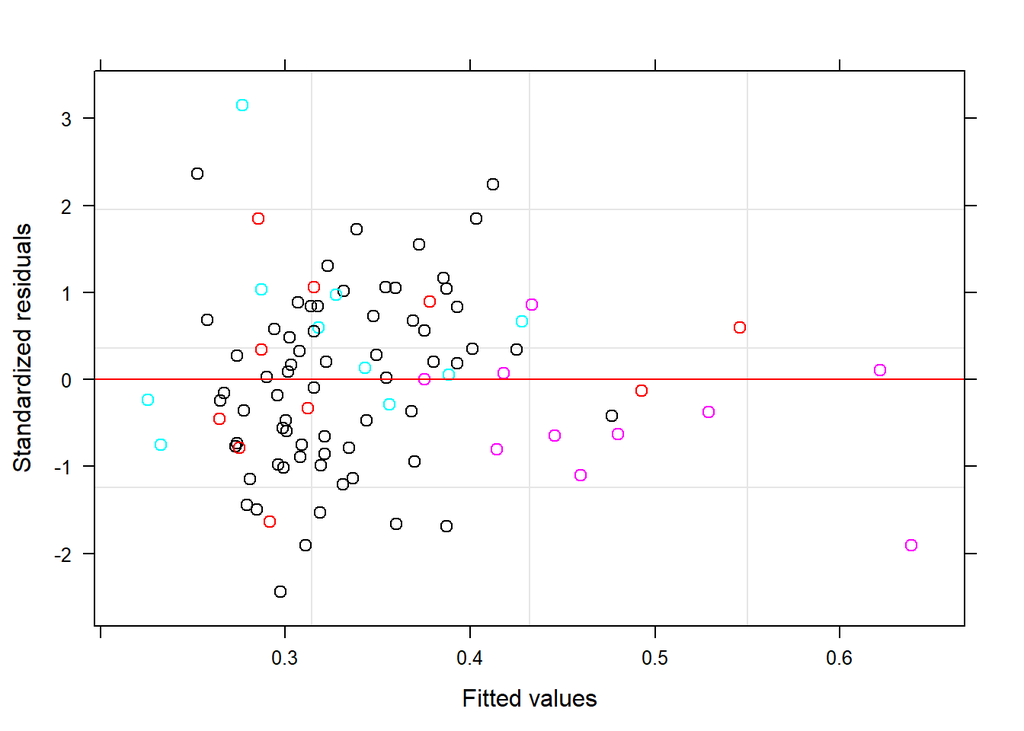

```r
E <- resid(LM2, type="normalized")
df_dia$resid <- E
plot(LM2, col = df_dia$Fire)
```

```r
df_dia[fitted.values(LM2)<0,]$resid
```

```
## numeric(0)
```

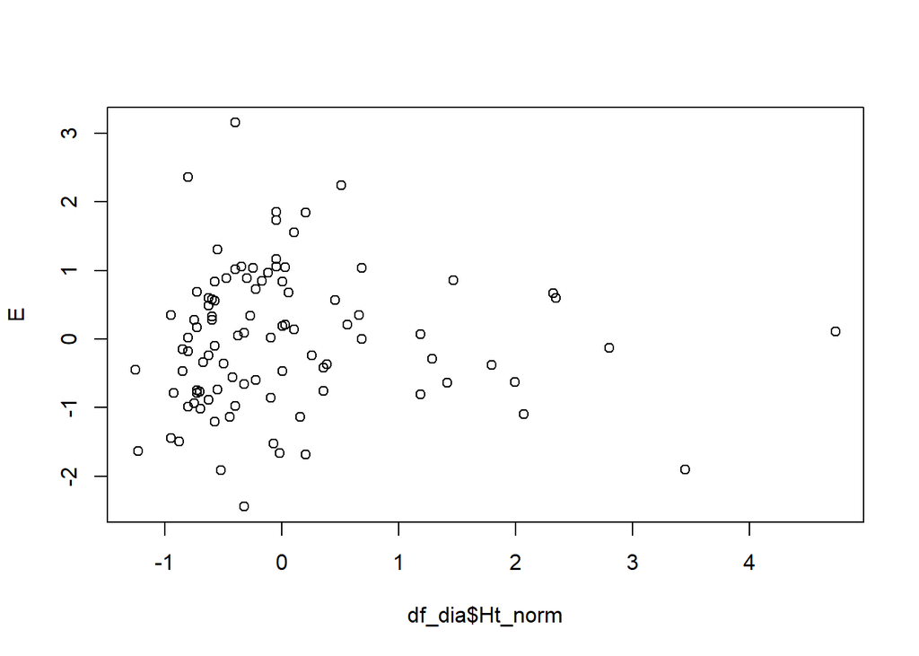

```r
plot(df_dia$Ht_norm, E)
```

# What about a variance structure in relation to height?

```r
f <- DiaGrowth.mm_rel ~  Cov1.2_norm + Ht_norm
f_null <- DiaGrowth.mm_rel ~ Ht_norm
LM3 <- lme(f,
           data = df_dia,
           random = ~ 1| Fire,
           method = "REML",
           weights = varExp(form=~Ht_norm))
LM2 <- lme(f,
           data = df_dia,
           random = ~ 1| Fire,
           method = "REML")
anova(LM3, LM2)
```

```
##     Model df       AIC       BIC   logLik   Test   L.Ratio p-value
## LM3     1  6 -105.2301 -89.78179 58.61503
## LM2     2  5 -107.0474 -94.17381 58.52368 1 vs 2 0.1826963  0.6691
```

Looks like a variance structure does not need to be included. Go back above and take it out of the AIC selection.